# Quantile Regression

Chris Cioffi, Kristina Frazier, Aidan Hennessy, Mike McHenry

## Quantile Regression

- A useful alternative to Ordinary Least Squares (OLS).
- Produces estimated regression coefficients for specific quantiles of the response variable.
  - As a result, the coefficients will change as the specified quantile of the response variable changes.

## Sample Density

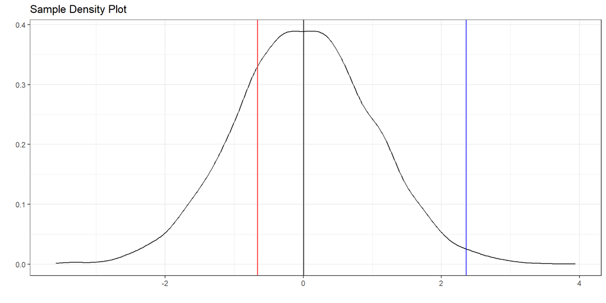

## Example of Linear and Quantile Trend Lines

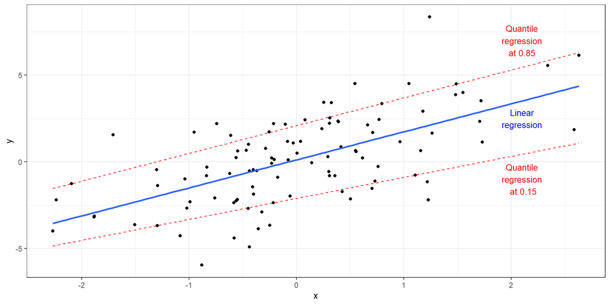

## Why Use Quantile Regression?

- The relationship between the predictor and response variables may vary across the distribution, making it useful to allow the estimates to change.
  - A richer description of the relationship.
- More robust to outliers.
- If OLS assumptions are violated.
  - Nonconstant variance, nonnormality, independence, nonlinearity.

## Differences in Minimization

- OLS: $\sum_{i}^{N}(e_i)^2$
- Quantile: $\sum \tau |e_i| + \sum(1-\tau) |e_i|$
  - $\tau |e_i|$ penalizes underprediction and $(1 - \tau) |e_i|$ penalizes overprediction

## Model Assumptions

- Large sample size.
- Response variable is continuous without a grouping of observations at one particular value.
- No strict distribution to adhere to.

## Quantreg Package

- The `lm()` function allows us to use linear regression and estimate the conditional mean of the response considering multiple explanatory variables.
- The `quantreg` package can be used to easily conduct quantile regression in R.
  - `rq()` is the key command in the package.
  - Documentation available on [CRAN](https://cran.r-project.org/web/packages/quantreg/index.html).

## Quantreg and WHO data

- Demo: estimate the conditional quantiles, considering the predictors, and here we can use quantreg to compare world nations’ life expectancies to its so-called income index.
- The dataset is maintained by the World Health Organization and looks at a variety of public health and income factors for world nations. We’re using a Kaggle version, which can be easily downloaded [here](https://gist.github.com/aishwarya8615/89d9f36fc014dea62487f7347864d16a).
- *Demo adapted from examples found on Medium and R-bloggers

## Quantreg and WHO data

- After removing nations with incomplete information, we can see a positive relationship between developed countries and higher life expectancy.

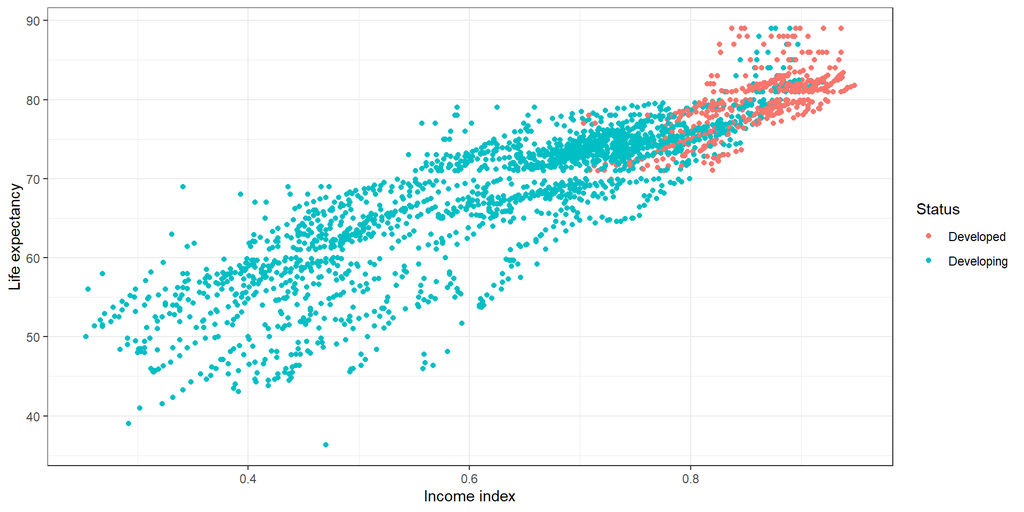

## Quantile regression vs Linear Regression

- While linear regression can give us the mean value, quantreg can allow us to find any quantile ranging from the 1st percentile to the 99th percentile.
- We can also easily evaluate the 50th percentile (the median) which can be more resistant to outliers than linear regression’s mean.

## Quantile vs Linear Regression

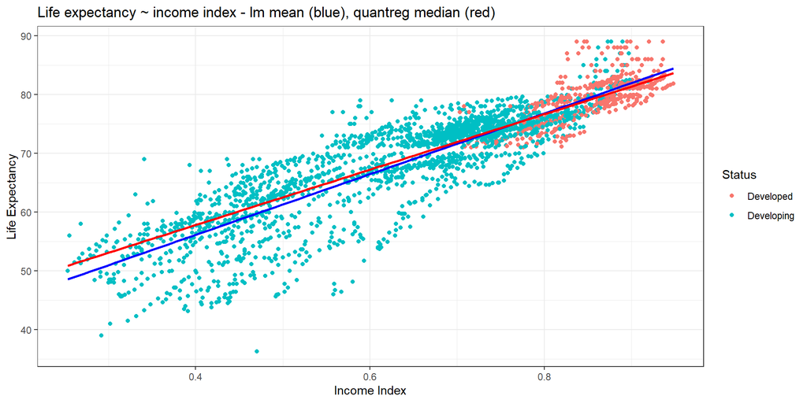

## Comparing the mean and median

- Compare confidence intervals for life expectancy using the median quantile regression and linear regression.

```r
notrqfit<- lm(Life_expectancy ~ Income_composition_of_resources,
              data = life_exp_narm)
rqfit50 <- rq(Life_expectancy ~ Income_composition_of_resources, tau = 0.50,
              data = life_exp_narm)
```

```
# A tibble: 3 × 3
  `95% Lower` `OLS Estimate` `95% Upper`
        <dbl>          <dbl>       <dbl>
1        62.3           62.6        62.8
2        71.2           71.3        71.5
3        76.2           76.4        76.6
```

```
# A tibble: 3 × 3
  `95% Lower` `Quantile Estimate` `95% Upper`
        <dbl>               <dbl>       <dbl>
1        63.4                63.7        64.0
2        71.5                71.7        71.9
3        76.1                76.3        76.5
```

## Quantreg for quantiles

- In addition to comparing the mean to the median, we can also look at the top and bottom quantiles to compare the confidence intervals for our estimated parameters. First run the different models and obtain the coefficients at each quantile:

```r
notrqfit<- lm(Life_expectancy ~ Income_composition_of_resources,
              data = life_exp_narm)
rqfit25 <- rq(Life_expectancy ~ Income_composition_of_resources,
              tau = 0.25, data = life_exp_narm)
rqfit50 <- rq(Life_expectancy ~ Income_composition_of_resources,
              tau = 0.50, data = life_exp_narm)
rqfit75 <- rq(Life_expectancy ~ Income_composition_of_resources,
              tau = 0.75, data = life_exp_narm)
rqfit99 <- rq(Life_expectancy ~ Income_composition_of_resources,
              tau = 0.99, data = life_exp_narm)
```

## Progression of the Coefficient

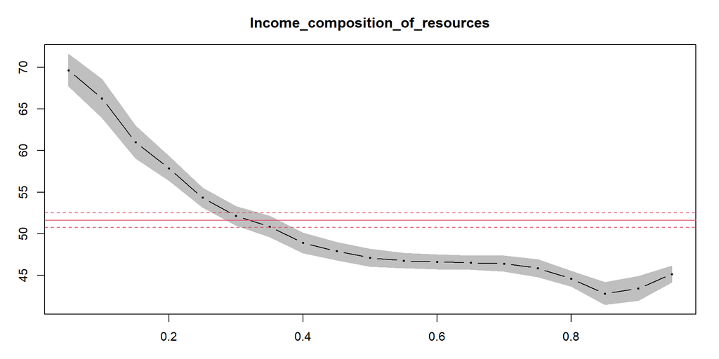

## Estimates at Different Quantiles

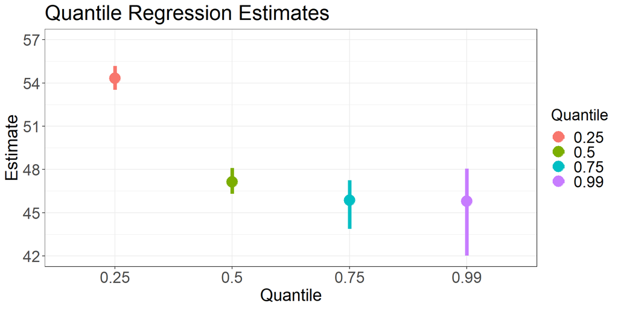

## Impact at Different Quantiles

- The impact of income on life expectancy is different depending on the quantile of life expectancy.
- It is very important to note that the intercept also changes based on the quantile.
  - This can lead to counterintuitive predictions of the response variable.
- Comparing the 25th quantile to the 75th quantile, it’s easy to see how different the life expectancy for those people would be depending on their income.

## Prediction at Different Quantiles

- Quantile regression results at 0.25 and 0.75.

```
# A tibble: 3 × 3
  `95% Lower` `Quantile Estimate` `95% Upper`
        <dbl>               <dbl>       <dbl>
1        59.5                60.0        60.5
2        68.9                69.2        69.5
3        74.4                74.5        74.7
```

```
# A tibble: 3 × 3
  `95% Lower` `Quantile Estimate` `95% Upper`
        <dbl>               <dbl>       <dbl>
1        65.7                66.0        66.4
2        73.7                73.8        74.0
3        78.2                78.3        78.5
```

## References

[Voxco Quantile Regression Blog](https://www.voxco.com/blog/quantile-regression/)

[Medium Quantile Regression Tutorial in R](https://drkebede.medium.com/quantile-regression-tutorial-in-r-f2eec72c132b)

[R Bloggers Quantile Regression in R](https://www.r-bloggers.com/2019/01/quantile-regression-in-r-2/)

[IBM Quantile Regression Page](https://www.ibm.com/docs/en/spss-statistics/saas?topic=regression-quantile)

[UVA Getting Started with Quantile Regression](https://library.virginia.edu/data/articles/getting-started-with-quantile-regression)

[APTECH The Basics of Quantile Regression](https://www.aptech.com/blog/the-basics-of-quantile-regression/)

[Towards Data Science Quantile Regression](https://towardsdatascience.com/quantile-regression-ff2343c4a03)

[Econometrics Academy Quantile Regression](https://www.youtube.com/watch?v=P9lMmEkXuBw)

[Econometrics Academy Quantile Regression Example](https://www.youtube.com/watch?v=qrriFC_WGj8)